# Как тип курса влияет на посещение форума

## 1. Об отчете

### Исследовательские вопросы

1. Какая доля студентов посещает форум?
2. Сколько страниц форума в среднем посещают студенты?
3. Как отличается среднее посещение форума на курсах из специализаций и не из специализаций?
4. Как отличается среднее посещение форума на курсах с заданиями по программированию и без них?

### Переменные

- **Метрики форума**
  - *student_vis_mean* - среднее посещение форума студентами на курсе;
  - *vis_b* - посещал форум или нет;
  - *vis_p* - количество посещенных страниц форума c удаленными выбросами;
- **Тип курса.**
  - *spec_b* - индивидуальный курс или курс из специализации;
  - *is_prog* - есть задания по программированию в курсе или нет;
- **Тип задания** - бинарные переменные; сообщают есть ли такой тип задания на курсе;
  - *is_prog* - есть ли задание по программированию;
  - *is_math* - есть ли задание по математике;
  - *is_peer* - есть ли пир-ревью;

### Как создавались бинарные переменные типов заданий

- К сожалению, не всегда удается автоматически определить какие на курсе задания, а потому приходится использовать разнообразные признаки для их кодирования.
- *is_prog*
  - есть ли в таблице course_items.csv задания со словом “programming”;
  - есть ли в таблице assessment_questions.csv вопросы с типом 14 (codeExpression);
- *is_math*
  - есть ли задания в таблице assessment_math_expression_questions.csv;
  - есть ли в таблице peer_assignment_submission_schema_parts.csv слова “math”,“calculate”, “Рассчитайте”;
- *is_peer*
  - есть ли в таблице ‘course_items.csv’ задание с типом 104 (peer-review);

### Описание данных

```r
table(courses$is_prog_b)
```

```
##
##  0  1
## 45 13
```

```r
table(courses$spec_b)
```

```
##
##  IND SPEC
##   37   21
```

### Удаление выбросов

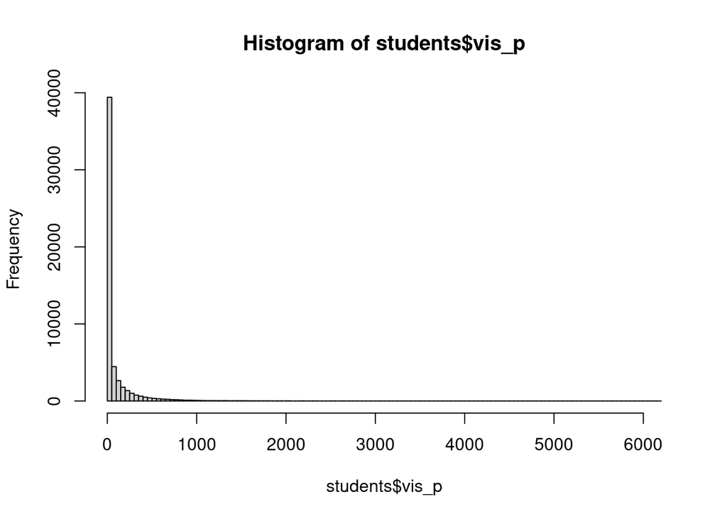

```r
hist(students$vis_p, breaks = 100)
```

```r
students <- students %>%
  mutate(vis_p = remove_outliers(vis_p))
```

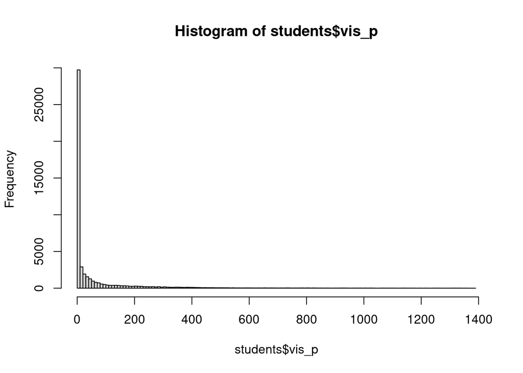

```r
hist(students$vis_p, breaks = 100)
```

## 2. Сколько студентов посещает форум и сколько страниц они посещают

### 2.1 Вероятность посещения форума студентом

```r
m0 <- glmer(factor(vis_b) ~ 1 + (1|course_id),
            family = binomial,
            students)
summary(m0)
```

```
## Generalized linear mixed model fit by maximum likelihood (Laplace
##   Approximation) [glmerMod]
##  Family: binomial  ( logit )
## Formula: factor(vis_b) ~ 1 + (1 | course_id)
##    Data: students
##
##      AIC      BIC   logLik deviance df.resid
##  56731.6  56749.5 -28363.8  56727.6    55375
##
## Scaled residuals:
##     Min      1Q  Median      3Q     Max
## -5.4334 -0.7868  0.2506  0.7006  1.6766
##
## Random effects:
##  Groups    Name        Variance Std.Dev.
##  course_id (Intercept) 1.428    1.195
## Number of obs: 55377, groups:  course_id, 58
##
## Fixed effects:
##             Estimate Std. Error z value Pr(>|z|)
## (Intercept)   0.9610     0.1555   6.179 6.47e-10 ***
## ---
## Signif. codes:  0 '***' 0.001 '**' 0.01 '*' 0.05 '.' 0.1 ' ' 1
```

Выясним опорную переменную:

```r
contrasts(students$vis_b)
```

```
##   1
## 0 0
## 1 1
```

Результаты:

```
##
## 2) Вероятность посещения форума на среднем курсе с учетом стандратного отклонения  равна 72% (через обратный логит интерсепта модели m0).
```

```
## Эта вероятность будет колебаться между: 44% и 90%.
```

```
## Необъясненная дисперсия (variance): 1.427563.
```

### 2.2 Количество страниц в среднем посещенных студентом

Выбор статистических инструментов:

1. Проверяем вариацию моделей, чтобы выбрать подходящее распредление
2. The square root of the scale parameter, according to recommendations by D. Bates, if its value is between 0.75 and 1.4, there may not be an overdispersion problem.

```r
m0 <- glmer(vis_p ~ 1 + (1|course_id), family='poisson',
            students)
```

```r
od <- dispersion_glmer(m0)
od
```

```
## [1] 8.674619
```

```r
m0 <- glmer.nb(vis_p ~ 1 + (1|course_id),
            students)
```

Проверка вариации модели:

```r
od <- dispersion_glmer(m0)
od
```

```
## [1] 1.02728
```

```r
summary(m0)
```

```
## Generalized linear mixed model fit by maximum likelihood (Laplace
##   Approximation) [glmerMod]
##  Family: Negative Binomial(0.4115)  ( log )
## Formula: vis_p ~ 1 + (1 | course_id)
##    Data: students
##
##       AIC       BIC    logLik  deviance  df.resid
##  360749.1  360775.6 -180371.6  360743.1     50016
##
## Scaled residuals:
##     Min      1Q  Median      3Q     Max
## -0.6411 -0.5880 -0.3734  0.2702  6.9057
##
## Random effects:
##  Groups    Name        Variance Std.Dev.
##  course_id (Intercept) 4.192    2.047
## Number of obs: 50019, groups:  course_id, 58
##
## Fixed effects:
##             Estimate Std. Error z value Pr(>|z|)
## (Intercept)   2.0218     0.1721   11.75   <2e-16 ***
## ---
## Signif. codes:  0 '***' 0.001 '**' 0.01 '*' 0.05 '.' 0.1 ' ' 1
```

```
##
## Cреднее количество страниц, которые посещают студенты на форуме среднего курса: 8
```

```
## Это количество колеблется между: 1 и 59 страницами
```

```
## Необъясненная дисперсия (variance): 4.192202
```

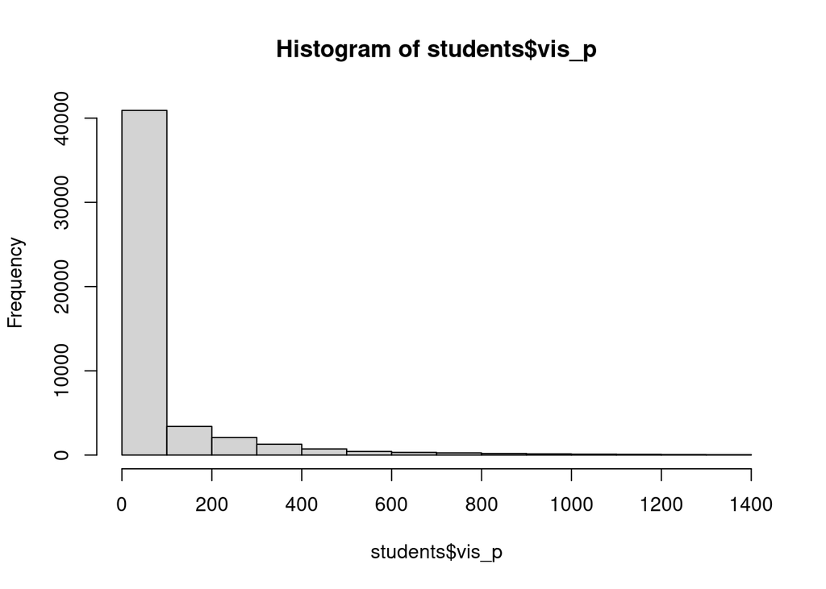

```r
hist(students$vis_p)
```

## 3. Как на посещение форума влияет вхождение курса в специализацию

### 3.1 Влияние специализации на посещение форума студентом

```r
#contrasts(students$spec_b)
m0 <- glmer(vis_b ~ spec_b +(1|course_id),
            family = binomial,
            students)
summary(m0)
```

```
## Generalized linear mixed model fit by maximum likelihood (Laplace
##   Approximation) [glmerMod]
##  Family: binomial  ( logit )
## Formula: vis_b ~ spec_b + (1 | course_id)
##    Data: students
##
##      AIC      BIC   logLik deviance df.resid
##  56733.6  56760.4 -28363.8  56727.6    55374
##
## Scaled residuals:
##     Min      1Q  Median      3Q     Max
## -5.4303 -0.7868  0.2506  0.7006  1.6767
##
## Random effects:
##  Groups    Name        Variance Std.Dev.
##  course_id (Intercept) 1.428    1.195
## Number of obs: 55377, groups:  course_id, 58
##
## Fixed effects:
##             Estimate Std. Error z value Pr(>|z|)
## (Intercept)  0.97044    0.18414   5.270 1.36e-07 ***
## spec_bSPEC  -0.02574    0.28908  -0.089    0.929
## ---
## Signif. codes:  0 '***' 0.001 '**' 0.01 '*' 0.05 '.' 0.1 ' ' 1
##
## Correlation of Fixed Effects:
##            (Intr)
## spec_bSPEC -0.542
```

```
## Незначимо!
```

### 3.2 Влияние специализации на количество страниц посещенных студентом

```r
m0 <- glmer.nb(vis_p ~ spec_b +(1|course_id),
            students)
summary(m0)
```

```
## Generalized linear mixed model fit by maximum likelihood (Laplace
##   Approximation) [glmerMod]
##  Family: Negative Binomial(0.4115)  ( log )
## Formula: vis_p ~ spec_b + (1 | course_id)
##    Data: students
##
##       AIC       BIC    logLik  deviance  df.resid
##  360749.1  360784.4 -180370.6  360741.1     50015
##
## Scaled residuals:
##     Min      1Q  Median      3Q     Max
## -0.6411 -0.5880 -0.3734  0.2702  6.9004
##
## Random effects:
##  Groups    Name        Variance Std.Dev.
##  course_id (Intercept) 4.049    2.012
## Number of obs: 50019, groups:  course_id, 58
##
## Fixed effects:
##             Estimate Std. Error z value Pr(>|z|)
## (Intercept)   1.7385     0.2510   6.927 4.29e-12 ***
## spec_bSPEC    0.7796     0.3933   1.982   0.0475 *
## ---
## Signif. codes:  0 '***' 0.001 '**' 0.01 '*' 0.05 '.' 0.1 ' ' 1
##
## Correlation of Fixed Effects:
##            (Intr)
## spec_bSPEC -0.536
```

```
##
## Среднее количество страниц на форуме, которые студенты посещают на индивидуальном курсе: 6
```

```
## Среднее количество страниц на форуме, которые студенты посещают на курсе из специализации: 12
```

```
## Эта вероятность будет колебаться между: 2 и 93.
```

```
## Ожидаемое значение посещенных страниц форума для курса из специализации выше в 2.18 раз, чем для индивидуального курса.
```

## 4. Как на посещение форума влияет наличие на курсе заданий по программированию

```r
library(car)
leveneTest(as.numeric(vis_b) ~ course_id, students)
```

```
## Levene's Test for Homogeneity of Variance (center = median)
##          Df F value    Pr(>F)
## group    57  135.13 < 2.2e-16 ***
##       55319
## ---
## Signif. codes:  0 '***' 0.001 '**' 0.01 '*' 0.05 '.' 0.1 ' ' 1
```

### 4.1 Влияние программирования на посещение форума студентом

```r
m0 <- glmer(factor(vis_b) ~ is_prog_b + (1|course_id), family = "binomial",
            students)
summary(m0)
```

```
## Generalized linear mixed model fit by maximum likelihood (Laplace
##   Approximation) [glmerMod]
##  Family: binomial  ( logit )
## Formula: factor(vis_b) ~ is_prog_b + (1 | course_id)
##    Data: students
##
##      AIC      BIC   logLik deviance df.resid
##  56731.6  56758.4 -28362.8  56725.6    55374
##
## Scaled residuals:
##     Min      1Q  Median      3Q     Max
## -5.3818 -0.7868  0.2505  0.7005  1.6767
##
## Random effects:
##  Groups    Name        Variance Std.Dev.
##  course_id (Intercept) 1.349    1.162
## Number of obs: 55377, groups:  course_id, 58
##
## Fixed effects:
##             Estimate Std. Error z value Pr(>|z|)
## (Intercept)   0.8315     0.1645   5.053 4.34e-07 ***
## is_prog_b     0.5326     0.2993   1.780   0.0751 .
## ---
## Signif. codes:  0 '***' 0.001 '**' 0.01 '*' 0.05 '.' 0.1 ' ' 1
##
## Correlation of Fixed Effects:
##           (Intr)
## is_prog_b -0.407
```

Результаты:

```
##
## Вероятность, посещения форума на курсе без программирования: 70%
```

```
## Вероятность, посещения форума на курсе с программированием: 80%
```

```
## Эта вероятность будет колебаться между: 55.00% и 93.00%.
```

### 4.2 Влияние программирования на количество страниц посещенных студентом

```r
m0 <- glmer.nb(vis_p ~ is_prog_b + (1|course_id),
            students)
summary(m0)
```

```
## Generalized linear mixed model fit by maximum likelihood (Laplace
##   Approximation) [glmerMod]
##  Family: Negative Binomial(0.4115)  ( log )
## Formula: vis_p ~ is_prog_b + (1 | course_id)
##    Data: students
##
##       AIC       BIC    logLik  deviance  df.resid
##  360740.9  360776.2 -180366.4  360732.9     50015
##
## Scaled residuals:
##     Min      1Q  Median      3Q     Max
## -0.6411 -0.5880 -0.3735  0.2700  6.9055
##
## Random effects:
##  Groups    Name        Variance Std.Dev.
##  course_id (Intercept) 3.496    1.87
## Number of obs: 50019, groups:  course_id, 58
##
## Fixed effects:
##             Estimate Std. Error z value Pr(>|z|)
## (Intercept)   1.5745     0.2229   7.063 1.63e-12 ***
## is_prog_b     1.9761     0.2842   6.952 3.60e-12 ***
## ---
## Signif. codes:  0 '***' 0.001 '**' 0.01 '*' 0.05 '.' 0.1 ' ' 1
##
## Correlation of Fixed Effects:
##           (Intr)
## is_prog_b -0.383
```

Результаты:

```
##
## Ожидаемое количество страниц на форуме, которые студенты посещают на курсах без программирования: 4.83.
```

```
## Ожидаемое количество страниц на форуме, которые студенты посещают на курсе с программированием: 34.83.
```

```
## Эта количество будет колебаться между: 5.37 и 225.94.
```

```
## Ожидаемое количество посещенных страниц форуме на курсах с программированию выше чем на курсах без программирования в 7.21 раз.
```

#### Визуализация

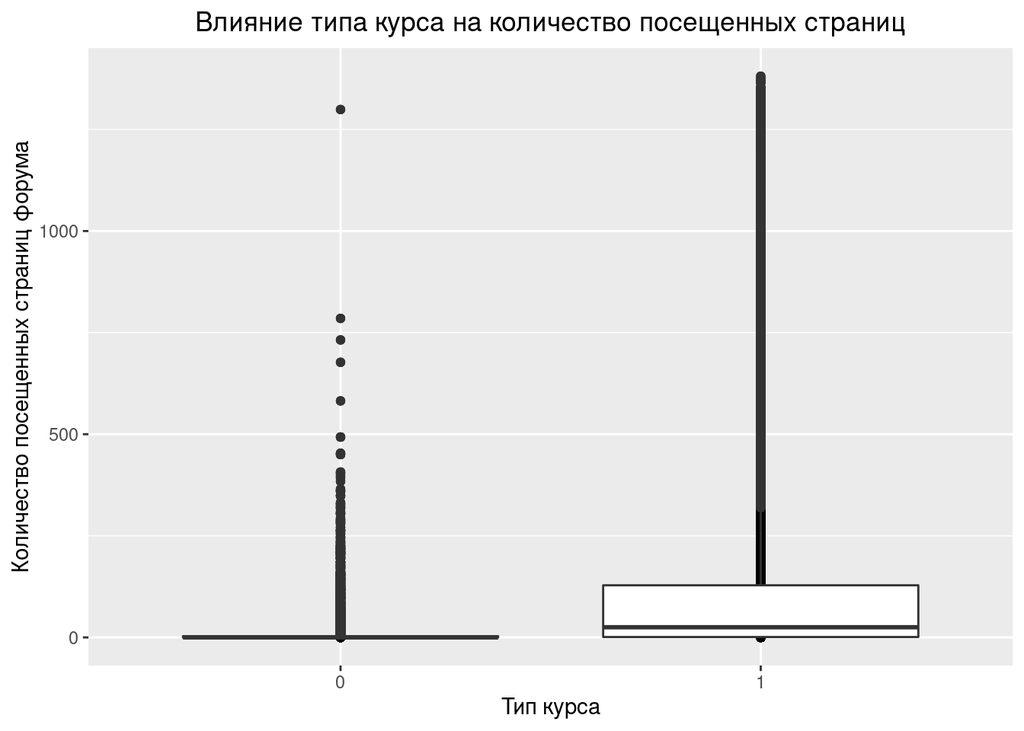

```r
students %>%
  ggplot(aes(x = factor(is_prog_b), y = vis_p)) + geom_point() + geom_boxplot() + ggtitle("Влияние типа курса на количество посещенных страниц") + labs(x="Тип курса", y = "Количество посещенных страниц форума") +  theme(plot.title = element_text(hjust = 0.5))
```

## 5. Как на среднее посещение форума на курсе влияет тип заданий на курсе

### 5.1 Описательная статистика

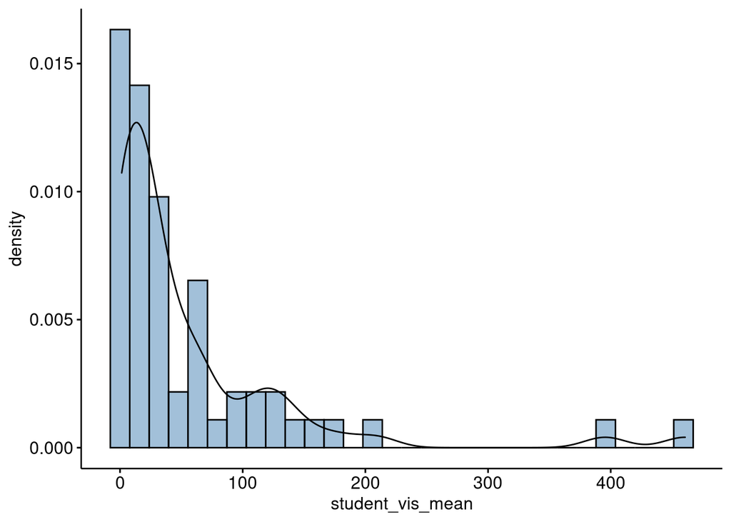

```r
gghistogram(courses, x = "student_vis_mean", y = "..density..",
            fill = "steelblue",bins = 30, add_density = TRUE)
```

```r
shapiro.test(courses$student_vis_mean)
```

```
##
##  Shapiro-Wilk normality test
##
## data:  courses$student_vis_mean
## W = 0.62415, p-value = 6.299e-11
```

### 5.2 Mann-Whitney U tests в виде расчетов и с силой эффекта

```r
wt1 <- wilcox.test(student_vis_mean ~ is_prog_b, courses)
w1 <- courses %>% wilcox_effsize(student_vis_mean ~ is_prog_b)
#wt2 <- wilcox.test(student_vis_mean ~ is_math_b, courses)
#w2 <- courses %>% wilcox_effsize(student_vis_mean ~ is_math_b)
#wt3 <- wilcox.test(student_vis_mean ~ is_peer_b, courses)
#w3 <- courses %>% wilcox_effsize(student_vis_mean ~ is_peer_b)
wt4 <- wilcox.test(student_vis_mean ~ spec_b, courses)
w4 <- courses %>% wilcox_effsize(student_vis_mean ~ spec_b)
```

```
##
##  Wilcoxon rank sum exact test
##
## data:  student_vis_mean by is_prog_b
## W = 132, p-value = 0.002154
## alternative hypothesis: true location shift is not equal to 0
```

```
## # A tibble: 1 x 7
##   .y.              group1 group2 effsize    n1    n2 magnitude
## * <chr>            <chr>  <chr>    <dbl> <int> <int> <ord>
## 1 student_vis_mean 0      1        0.393    45    13 moderate
```

```
##
##  Wilcoxon rank sum exact test
##
## data:  student_vis_mean by spec_b
## W = 263, p-value = 0.04245
## alternative hypothesis: true location shift is not equal to 0
```

```
## Effect size (r)
##       0.2666145
```

### 5.3 Mann-Whitney U tests в виде графиков

На графиках указаны статистики теста и значимость различий между курсами с разными типами заданий.

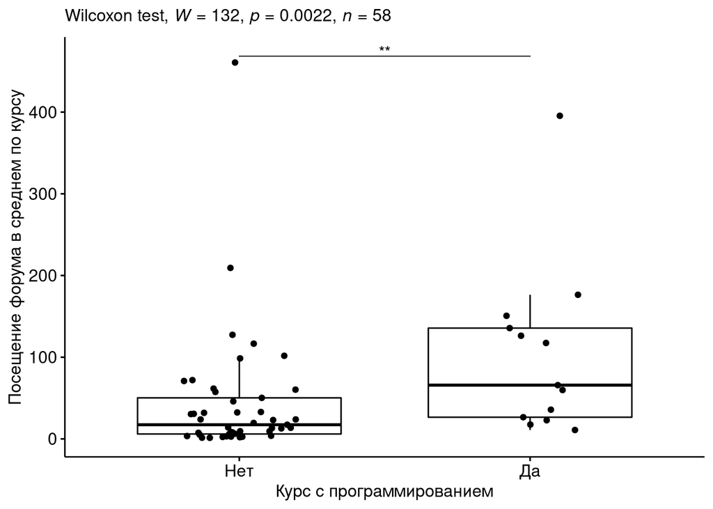

```r
stat.test <- courses %>%
  wilcox_test(student_vis_mean ~ is_prog_b) %>%
  add_significance()
bxp <- ggboxplot(
  courses, x = "is_prog_b", y = "student_vis_mean",
  ylab = "Посещение форума в среднем по курсу", xlab = "Курс с программированием", add = "jitter") +
scale_x_discrete(labels=c("Нет","Да"))
stat.test <- stat.test %>% add_xy_position(x = "group")
bxp +
  stat_pvalue_manual(stat.test, tip.length = 0) +
  labs(subtitle = get_test_label(stat.test, detailed = TRUE))
```

[figure not shown]

```r
stat.test <- courses %>%
  wilcox_test(student_vis_mean ~ spec_b) %>%
  add_significance()
bxp <- ggboxplot(
  courses, x = "spec_b", y = "student_vis_mean",
  ylab = "Посещение форума в среднем по курсу", xlab = "Курс входит в специализацию", add = "jitter") +
scale_x_discrete(labels=c("Нет","Да"))
stat.test <- stat.test %>% add_xy_position(x = "group")
bxp +
  stat_pvalue_manual(stat.test, tip.length = 0) +
  labs(subtitle = get_test_label(stat.test, detailed = TRUE))
```

### 5.4 Рассчет медиан

```r
students %>% group_by(is_prog_b) %>% summarize(median = median(as.numeric(vis_p), na.rm = TRUE))
```

```
## # A tibble: 2 x 2
##   is_prog_b median
##       <int>  <dbl>
## 1         0      0
## 2         1     25
```

```r
students %>% group_by(spec_b) %>% summarize(median = median(as.numeric(vis_p), na.rm = TRUE))
```

```
## # A tibble: 2 x 2
##   spec_b median
##   <fct>   <dbl>
## 1 IND         3
## 2 SPEC        6
```